# Bike-Sharing and Transportation

### Overview

In this report, I will show that probably most of the clients of the bike-sharing busnisses use the bikes as a transportation to go to thier work or school and most of them are regular subscribers. The main focus will be on the duration and the distribution of rides over days and hours.

### Dataset Overview

The dataset consists of the duration and attributes for 183412 ride covering the greater San Francisco Bay area, and the dataset only includes Febuary, 2019 rides. The attributes that are included in the dataset are ('duration_sec', 'start_time', 'end_time', 'start_station_id','start_station_name', 'start_station_latitude', 'start_station_longitude', 'end_station_id', 'end_station_name', 'end_station_latitude', 'end_station_longitude', 'bike_id', 'user_type', 'member_birth_year', 'member_gender' and 'bike_share_for_all_trip')

the attributes that I included in my investgation are duration_sec, start_time, start and stop station longitude and latitude, user_type, member_birth_year and member_gender

## The Distribution of Duration Variable

The duration variable represents how long the ride have been in seconds. Most of the rides took around 10 to 32 mins.

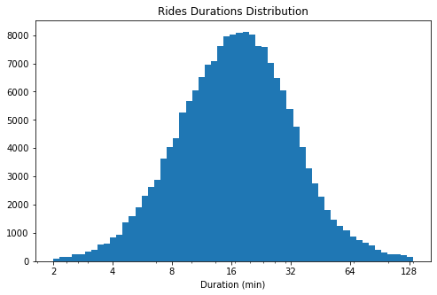

## The Distribution of Distance Variable

The Distance variable represents the difference between the start and end stations takes in kilometers. Most of the rides were between 1 and 3 kilometers.

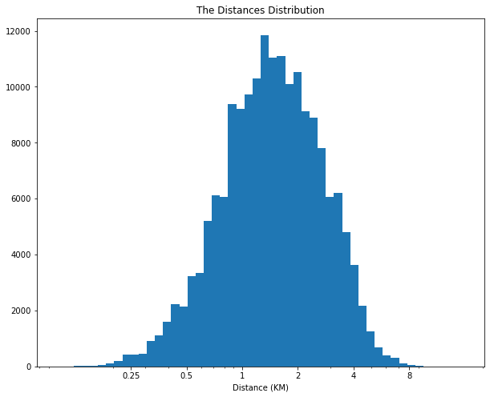

## The Frequency of Rides over Weekdays

work days have higher number of rides.

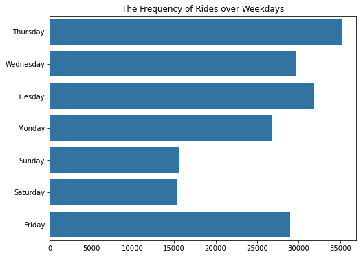

## Weekdays and user types and gender

it appers that the number of customers isn't affected by the day, in contrast subscribers are more common to ride in working days.

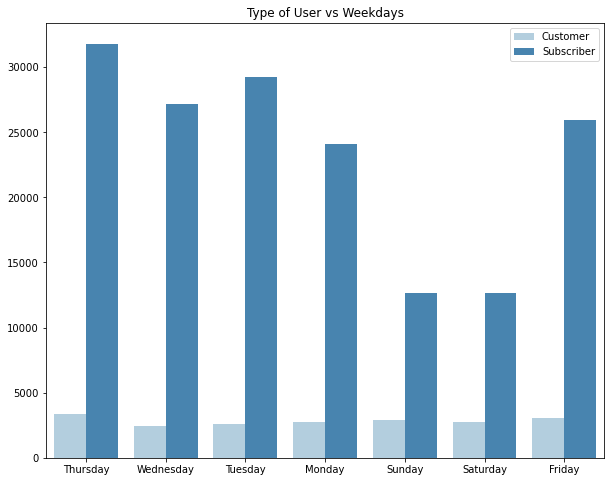

## Day Hours vs Weekday

- The distribution of rides over the hours of day is bimodal for all working days with one peak between 7 and 9 AM and another peak between 4 and 6 PM
- It transforms to unimodal for weekends with one spike between 12 and 5 pm.
- Therefore the most frequant rides are on working days, the most frequent hours are when workers go and come back from their work.

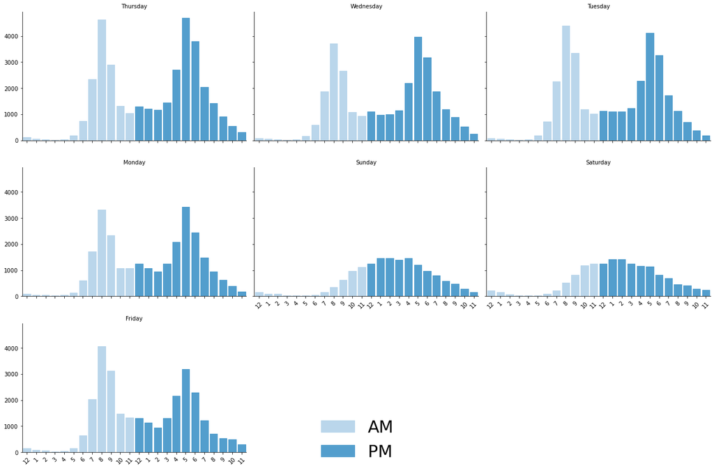

## Weekdays and User Type by Duration

The average duration is higher for customers than subscribers, it also has more variation. and the avg duration in general increases on weekends.

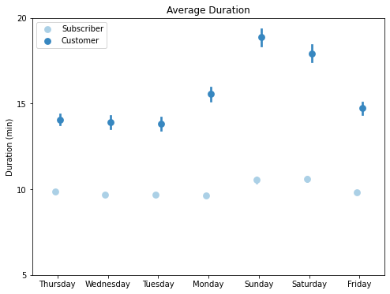